# Team

Kenneth Mendoza

November 13, 2019

```r
library(ggplot2)
library(tidyr)
library(dplyr)
df = read.table('diabetes.txt',header=TRUE)
df$frame = droplevels(df$frame,"")

df$frame= as.character(df$frame)
df = subset(df, select = -c(1, 15:16))
diabetes_clean = na.omit(df)
df$frame[is.na(df$frame)] = 'NA'
df$frame = as.factor(df$frame)

diabetes_reduced = subset(df, select = -c(1, 15:16))

is.na(diabetes_clean)
```

[output not shown]

[output cut: 719 more lines]

```r
summary(diabetes_clean$glyhb)
```

```
##    Min. 1st Qu.  Median    Mean 3rd Qu.    Max.
##   2.680   4.393   4.860   5.607   5.630  16.110
```

```r
as.factor(diabetes_clean$glyhb)
```

[output not shown]

[output cut: 60 more lines]

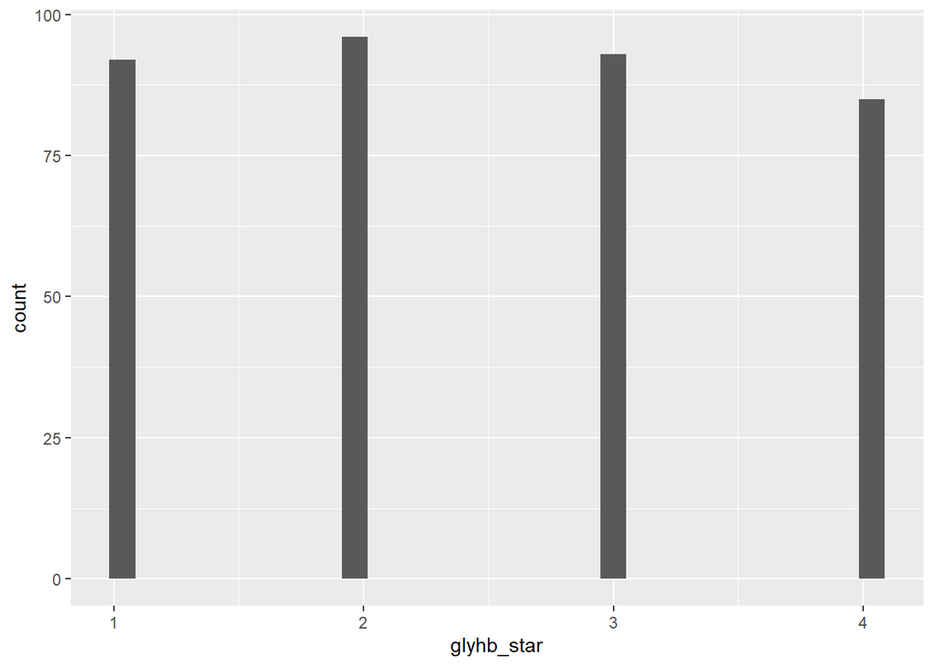

```r
diabetes_clean$glyhb_star[diabetes_clean$glyhb<4.4] = 1
diabetes_clean$glyhb_star[diabetes_clean$glyhb>=4.4 & diabetes_clean$glyhb <4.9 ] = 2
diabetes_clean$glyhb_star[diabetes_clean$glyhb>=4.9 & diabetes_clean$glyhb <5.7 ] = 3
diabetes_clean$glyhb_star[diabetes_clean$glyhb>5.7 & diabetes_clean$glyhb <17 ] = 4
ggplot(diabetes_clean, aes(glyhb_star)) + geom_histogram()
```

```r
diabetes_clean %>% group_by(frame) %>% summarise(mean.glyhb = mean(glyhb_star))
```

```
## # A tibble: 3 x 2
##   frame  mean.glyhb
##   <chr>       <dbl>
## 1 large        2.84
## 2 medium       2.47
## 3 small        2.09
```

```r
diabetes_clean %>% group_by(frame,location) %>% summarise (mean.glyhb_star= mean(glyhb_star))
```

```
## # A tibble: 6 x 3
## # Groups:   frame [3]
##   frame  location   mean.glyhb_star
##   <chr>  <fct>                <dbl>
## 1 large  Buckingham            3.02
## 2 large  Louisa                2.58
## 3 medium Buckingham            2.62
## 4 medium Louisa                2.36
## 5 small  Buckingham            1.95
## 6 small  Louisa                2.2
```

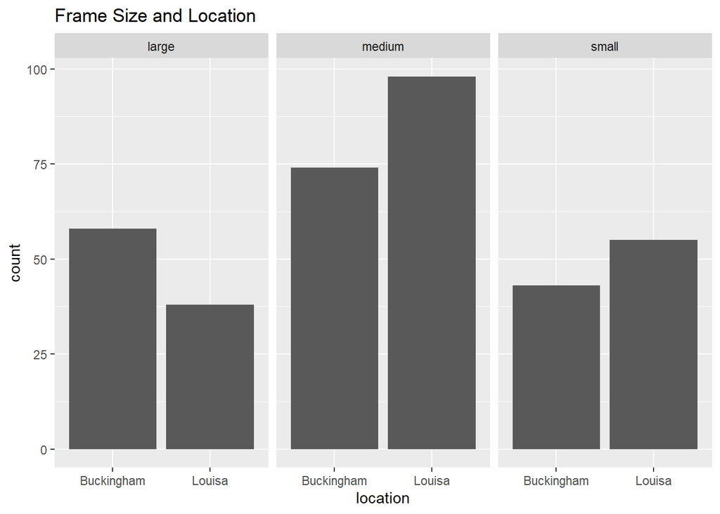

```r
ggplot(diabetes_clean, aes(x=location)) + geom_bar() + facet_wrap(~frame) + ggtitle("Frame Size and Location")
```

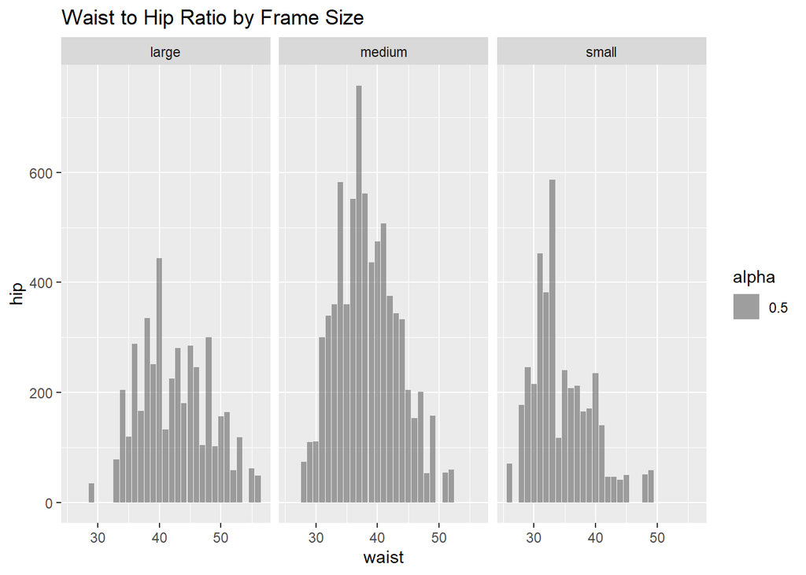

```r
ggplot(diabetes_clean,aes(y=hip,x=waist,alpha=0.5)) + geom_col() + facet_wrap(~frame) + ggtitle("Waist to Hip Ratio by Frame Size")
```

**Gather and Spread**

The Gather command reshapes data from a wide format to a long format. The Spread command does the opposite, reshaping data from a long format to a wide format. This makes the 2 commands complements of each other since they are inversely proportional.

```r
fit = lm(glyhb_star ~stab.glu + age + waist + ratio+ factor(frame),data=diabetes_clean)
 summary(fit)
```

```
##
## Call:
## lm(formula = glyhb_star ~ stab.glu + age + waist + ratio + factor(frame),
##     data = diabetes_clean)
##
## Residuals:
##     Min      1Q  Median      3Q     Max
## -2.5256 -0.6297  0.0110  0.6489  2.5436
##
## Coefficients:
##                       Estimate Std. Error t value Pr(>|t|)
## (Intercept)         -0.4729369  0.4144330  -1.141  0.25456
## stab.glu             0.0070663  0.0009258   7.632 2.10e-13 ***
## age                  0.0187561  0.0030064   6.239 1.24e-09 ***
## waist                0.0250029  0.0094071   2.658  0.00821 **
## ratio                0.0812774  0.0286893   2.833  0.00487 **
## factor(frame)medium  0.0181767  0.1193783   0.152  0.87907
## factor(frame)small  -0.0755654  0.1479375  -0.511  0.60981
## ---
## Signif. codes:  0 '***' 0.001 '**' 0.01 '*' 0.05 '.' 0.1 ' ' 1
##
## Residual standard error: 0.8777 on 359 degrees of freedom
## Multiple R-squared:  0.3787, Adjusted R-squared:  0.3683
## F-statistic: 36.48 on 6 and 359 DF,  p-value: < 2.2e-16
```

F-statistic = 36.48 Adj. R squared = 0.3683

An inference is a conclusion made after data analysis is conducted, usually based on the results. A prediction is made before analysis and is based on less evidence than an inference.

A linear regression model is simple and quick. For many datasets, it can be accurate enough. However, a KNN regression can be more accurate in many cases, but is far more complicated and requires more time to compile and run.

Largely, our views have not changed much on data science. We still believe it is the aquisition, cleaning, predicting, and presenting of data using a variety of software tools. The variety of interactive graphs we were shown in class were the most surprising to us. We found the cleaning and dataframe manipulation to be most challenging, as lining up columns for joining can be tricky. Finally, we found graphing and displays to be most enjoyable, as it turns plaintext data into stunning visual displays that can be much easier to decipher.